# Linear Regression

**`Author : Alhasan Gamal Mahmoud`**

**`Date : 17 - 02 - 2022`**

**In this Script, I will develop a Python program that is able to implement gradient descent in order to achieve the linear regression of a set of data points.**

#### Read RegData csv file into numpy array (check your data)

##### Data source

https://college.cengage.com/mathematics/brase/understandable_statistics/7e/students/datasets/slr/frames/frame.html

## Linear Regression for Sigle Variable

**Hypothesis:** \begin{equation} h(\theta) = \theta_0 + \theta_1 x \end{equation} **Parameters:** \begin{equation} \theta_0 , \theta_1 \end{equation} **Cost Function:** \begin{equation} J(\theta) = 1/2m \sum_{i=1}^{m} (h(\theta)^{(i)} - y^{(i)})^2 \end{equation} **Goal:** \begin{equation} mimimize j(\theta_0 , \theta_1) \end{equation}

**Gradient**

\begin{equation} \frac{\partial J(\theta)}{\partial \theta_j} = 1/m\sum_{i=1}^{m}(h(\theta^{(i)} - y^{(i)}).X_j^{(i)} \end{equation}

**Gradients** \begin{equation} \theta_0: = \theta_0 -\alpha . (1/m .\sum_{i=1}^{m}(h(\theta^{(i)} - y^{(i)}).X_0^{(i)}) \end{equation} \begin{equation} \theta_1: = \theta_1 -\alpha . (1/m .\sum_{i=1}^{m}(h(\theta^{(i)} - y^{(i)}).X_1^{(i)}) \end{equation}

#### Gradient Descent

Gradient descent is an optimization technique used for computing the model parameters (coefficients and bias) for algorithms like linear regression, logistic regression, neural networks, etc. In this technique, we repeatedly iterate through the training set and update the model parameters in accordance with the gradient of the error with respect to the training set.

[figure not shown]

##### Depending on the number of training examples considered in updating the model parameters, we have 3-types of gradient descents:

1) **Batch Gradient Descent**

2) **Stochastic Gradient Descent**

3) **Mini-Batch Gradient Descent**

#### Batch Gradient Descent

Parameters are updated after computing the gradient of error with respect to the entire training set

Batch Gradient Descent is great for convex or relatively smooth error manifolds. In this case, we move somewhat directly towards an optimum solution.

[figure not shown]

The graph of cost vs epochs is also quite smooth because we are averaging over all the gradients of training data for a single step. The cost keeps on decreasing over the epochs.

[figure not shown]

### LR Full Implenentation for Single variable

```python
# import libraries
import numpy as np
import pandas as pd
import matplotlib.pyplot as plt
%matplotlib inline
plt.style.use(['ggplot'])
```

```python
# read data
data = pd.read_csv("RegData.csv",header=None,names=['X', 'Y'])
```

```python
# show data details
print(f"Data:\n{data.head()}")
print("====================================")
print(f"Data Describe:\n{data.describe()}")
print("====================================")
print(f"Data Info:\n{data.info()}")
```

```
Data:
     X    Y
0  2.9  4.0
1  6.7  7.4
2  4.9  5.0
3  7.9  7.2
4  9.8  7.9
====================================
Data Describe:
               X          Y
count  13.000000  13.000000
mean    5.953846   5.569231
std     1.714942   1.314271
min     2.900000   4.000000
25%     4.900000   4.400000
50%     6.000000   5.200000
75%     6.700000   6.100000
max     9.800000   7.900000
====================================
<class 'pandas.core.frame.DataFrame'>
RangeIndex: 13 entries, 0 to 12
Data columns (total 2 columns):
 #   Column  Non-Null Count  Dtype
---  ------  --------------  -----
 0   X       13 non-null     float64
 1   Y       13 non-null     float64
dtypes: float64(2)
memory usage: 336.0 bytes
Data Info:
None
```

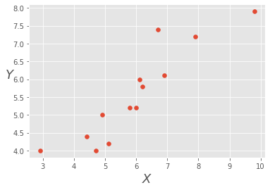

```python
# draw data
plt.scatter(data.X,data.Y)

plt.xlabel("$X$",fontsize=18)

plt.ylabel("$Y$",rotation=0,fontsize=18)

plt.show()
```

```python
# separate X (training data) from Y (target varaiable)
X_train = data.iloc[:,0]
y_train = data.iloc[:,1]
```

```python
# Explor X and y
print(f"X_Data = \n {X_train.head()}")
print(f"y_data = \n {y_train.head()}")
```

```
X_Data =
 0    2.9
1    6.7
2    4.9
3    7.9
4    9.8
Name: X, dtype: float64
y_data =
 0    4.0
1    7.4
2    5.0
3    7.2
4    7.9
Name: Y, dtype: float64
```

```python
# Step1: Initialize parameters (theta_0 & theta_1) with random value or simply zero. Also choose the Learning rate.

X = np.array(X_train)

y = np.array(y_train)

theta0 = theta1 = 0

alpha = 0.01
```

```python
# Step2: Use (theta_0 & theta_1) to predict the output h(x)= theta_0 + theta_1 * x.

h = theta0 + theta1 * X
```

```python
# Step3: Calculate Cost function 𝑱(theta_0,theta_1 ).
m = len(X)

j = np.sum(np.power((h - y),2)) / (2 * m)

print(f"Cost Function = {j}")
```

```
Cost Function = 16.305384479692318
```

```python
# Step4: Calculate the gradient for each theta.

gd0 = np.sum(h - y) / m

gd1 = np.sum((h - y) * X) / m

print(f"gd0 = {gd0}\ngd1 = {gd1}")
```

```
gd0 = -5.56923073976923
gd1 = -35.043846043215375
```

```python
# Step5: Update the parameters (simultaneously).

temp0  = theta0 - alpha * gd0

temp1  = theta1 - alpha * gd1

theta0 = temp0

theta1 = temp1

print(f"theta0 = {theta0}\ntheta1 = {theta1}")
```

```
theta0 = 0.0556923073976923
theta1 = 0.35043846043215376
```

```python
# Step6: Repeat from 2 to 5 until converge to the minimum or achieve maximum iterations.

cost    = []
thetas0 = []
thetas1 = []
hyposes = []
X = np.array(X_train)
y = np.array(y_train)
theta0 = theta1 = 0
alpha  = 0.05
Epochs = 1000
for i in range(Epochs):
    h      = theta0 + X * theta1
    hyposes.append(h)
    j      = np.sum(np.power((h-y),2))/(2*m)
    cost.append(j)
    gd0    = np.sum(h-y) / m
    gd1    = np.sum((h-y) * X) / m
    temp0  = theta0 - alpha * gd0
    temp1  = theta1 - alpha * gd1
    theta0 = temp0
    thetas0.append(theta0)
    theta1 = temp1
    thetas1.append(theta1)
    if i > 0:
        if np.abs(cost[i-1] - cost[i]) < 0.0001:
            break
        if np.abs(np.linalg.norm([thetas0[i-1],thetas1[i-1]]) - np.linalg.norm([thetas0[i],thetas1[i]])) < 0.0001:
            break
print(f"New Cost = {cost[-1]}")
```

```
New Cost = 0.16329561239265386
```

```python
# Predict y values using the LR equation [h(x)= theta_0 + theta_1 * x]

y_hat = theta0 + theta1 * X
```

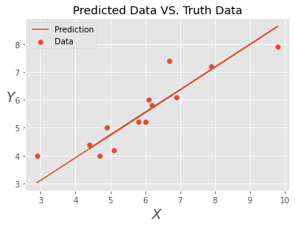

```python
# Plot LR equation output (fitted line) with the original data (scatter plot of X,y)

plt.plot(X,y_hat,label='Prediction')

plt.scatter(X,y,label='Data')

plt.legend()

plt.xlabel("$X$",fontsize=18)

plt.ylabel("$Y$",rotation=0,fontsize=18)

plt.title("Predicted Data VS. Truth Data")

plt.show()
```

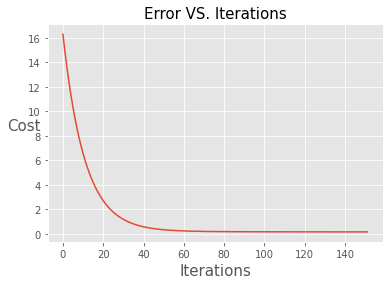

```python
# draw Error Graph
plt.plot(cost)
plt.xlabel("Iterations",fontsize=15)
plt.ylabel("Cost",rotation=0,fontsize=15)
plt.title("Error VS. Iterations",fontsize=15)
plt.show()
```

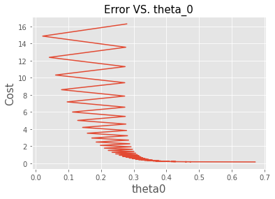

```python
# draw Error and theta0 graph
plt.plot(thetas0,cost)
plt.xlabel("theta0",fontsize=15)
plt.ylabel("Cost",fontsize=15)
plt.title("Error VS. theta_0",fontsize=15)
plt.show()
```

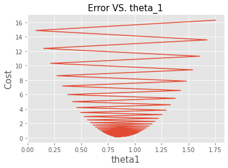

```python
# draw Error and theta1 graph
plt.plot(thetas1,cost)
plt.xlabel("theta1",fontsize=15)
plt.ylabel("Cost",fontsize=15)
plt.title("Error VS. theta_1",fontsize=15)
plt.show()
```

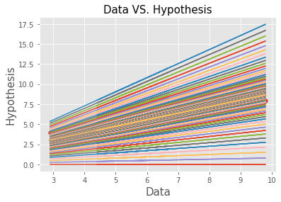

```python
# draw Error and Hypothesis graph
plt.scatter(X,y,label='Data')
for i in  hyposes:
    plt.plot(X,i)

plt.xlabel("Data",fontsize=15)
plt.ylabel("Hypothesis",fontsize=15)
plt.title("Data VS. Hypothesis",fontsize=15)
plt.show()
```

```python
# use R2 score to evaluate LR equation output
from sklearn.metrics import r2_score

r2_score(y,y_hat)
```

```
0.7953510527000996
```

### LR Vectorize Implementation for Single variable

```python
# read data

data_v = pd.read_csv("RegData.csv",header=None,names=['X', 'Y'])
data_v.head()
```

|  | X | Y |
| --- | --- | --- |
| 0 | 2.9 | 4.0 |
| 1 | 6.7 | 7.4 |
| 2 | 4.9 | 5.0 |
| 3 | 7.9 | 7.2 |
| 4 | 9.8 | 7.9 |

```python
# adding a new coulmn called ones before data (θ0)
data_v.insert(0,'X0',1)
print(f"new data :\n{data_v.head()}")
```

```
new data :
   X0    X    Y
0   1  2.9  4.0
1   1  6.7  7.4
2   1  4.9  5.0
3   1  7.9  7.2
4   1  9.8  7.9
```

```python
# separate X (training data) from Y (target varaiable)

X = data_v.iloc[:,:2]
Y = data_v.iloc[:,2]
print(f"X data=\n {X.head()}")
print(f"Y data=\n {Y.head()}")
```

```
X data=
    X0    X
0   1  2.9
1   1  6.7
2   1  4.9
3   1  7.9
4   1  9.8
Y data=
 0    4.0
1    7.4
2    5.0
3    7.2
4    7.9
Name: Y, dtype: float64
```

```python
# convert from data frames to numpy matrices
X = np.matrix(X.values)
y = np.matrix(Y.values).reshape((13,1))
theta = np.matrix(np.array([0,0]))
```

```python
# display shapes of X, y, theta

print(f"X.shape = {X.shape}")
print(f"y.shape = {y.shape}")
print(f"theta.shape = {theta.shape}")
```

```
X.shape = (13, 2)
y.shape = (13, 1)
theta.shape = (1, 2)
```

```python
# cost function
def ComputeCost(X,y,theta):
    z = np.power(((X * theta.T) - y),2)
    return np.sum(z) / (2 * len(X))
print(f"ComputeCost(X,y,theta) = {ComputeCost(X,y,theta)}")
```

```
ComputeCost(X,y,theta) = 16.305384479692318
```

```python
# GD function
def GradientDescent(X,y,theta,alpha,iters):
    temp = np.matrix(np.zeros(theta.shape))
    parameters = int(theta.ravel().shape[1])
    cost = []
    thetas = np.zeros((iters,parameters))
    hs = []

    for i in range(iters):
        error = (X * theta.T) - y
        hs.append(X * theta.T)
        for j in range(parameters):
            term = np.multiply(error, X[:,j])
            temp[0,j] = theta[0,j] - ((alpha / len(X)) * np.sum(term))

        theta = temp
        thetas [i,:] =theta
        cost.append(ComputeCost(X, y, theta))
        if i>0:
            if np.abs(cost[i-1] - cost[i]) < 0.0001:
                break
    return theta, cost,thetas,hs
```

```python
# perform gradient desent to fit the model parameters
new_theta, cost,thetas,hs = GradientDescent(X,y,theta,0.05,1000)
thetas=thetas[thetas !=0]
thetas = np.array(thetas).reshape(len(cost),2)
print(f"new theta = {new_theta}\n")
# print(f"cost = {cost}\n")
print(f"ComputeCost = {ComputeCost(X,y,new_theta)}")
```

```
new theta = [[0.79988447 0.79372388]]

ComputeCost = 0.15675881686769727
```

```python
# Predict y values using the LR equation [h(x)= theta_0 + theta_1 * x]
f = X @ new_theta.T
```

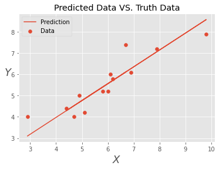

```python
# Plot LR equation output (fitted line) with the original data (scatter plot of X,y)

plt.plot(X[:,1],f,label='Prediction')

plt.scatter(data_v.X,data_v.Y,label='Data')

plt.legend()

plt.xlabel("$X$",fontsize=18)

plt.ylabel("$Y$",rotation=0,fontsize=18)

plt.title("Predicted Data VS. Truth Data")

plt.show()
```

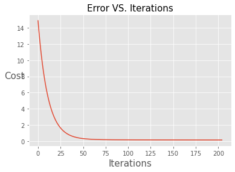

```python
# draw Error Graph
plt.plot(cost)
plt.xlabel("Iterations",fontsize=15)
plt.ylabel("Cost",rotation=0,fontsize=15)
plt.title("Error VS. Iterations",fontsize=15)
plt.show()
```

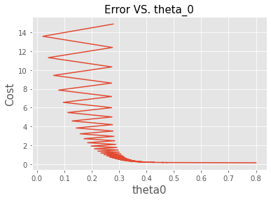

```python
# draw Error and theta0 graph
plt.plot(thetas[:,0],cost)
plt.xlabel("theta0",fontsize=15)
plt.ylabel("Cost",fontsize=15)
plt.title("Error VS. theta_0",fontsize=15)
plt.show()
```

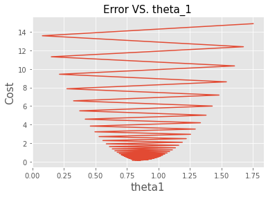

```python
# draw Error and theta1 graph
plt.plot(thetas[:,1],cost)
plt.xlabel("theta1",fontsize=15)
plt.ylabel("Cost",fontsize=15)
plt.title("Error VS. theta_1",fontsize=15)
plt.show()
```

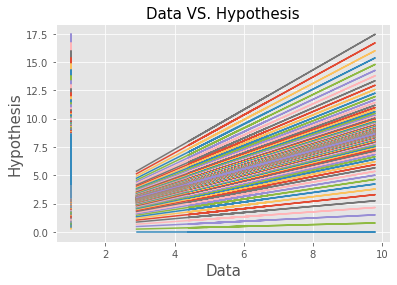

```python
# draw Error and Hypothesis graph
for i in  hyposes:
    plt.plot(X,i)

plt.xlabel("Data",fontsize=15)
plt.ylabel("Hypothesis",fontsize=15)
plt.title("Data VS. Hypothesis",fontsize=15)
plt.show()
```

```python
# use R2 score to evaluate LR equation output
from sklearn.metrics import r2_score

r2_score(np.asarray(y),np.asarray(f))
```

```
0.8033679276526594
```

## Multivariate LR

##### Data source

https://college.cengage.com/mathematics/brase/understandable_statistics/7e/students/datasets/slr/frames/frame.html

```python
# read data

m_data = pd.read_csv("MultipleLR.csv",header=None,names=['X1','X2','X3','X4'])
```

```python
# show data details
print(f"Data:\n{data.head()}")
print("====================================")
print(f"Data Describe:\n{data.describe()}")
print("====================================")
print(f"Data Info:\n{data.info()}")
```

```
Data:
     X    Y
0  2.9  4.0
1  6.7  7.4
2  4.9  5.0
3  7.9  7.2
4  9.8  7.9
====================================
Data Describe:
               X          Y
count  13.000000  13.000000
mean    5.953846   5.569231
std     1.714942   1.314271
min     2.900000   4.000000
25%     4.900000   4.400000
50%     6.000000   5.200000
75%     6.700000   6.100000
max     9.800000   7.900000
====================================
<class 'pandas.core.frame.DataFrame'>
RangeIndex: 13 entries, 0 to 12
Data columns (total 2 columns):
 #   Column  Non-Null Count  Dtype
---  ------  --------------  -----
 0   X       13 non-null     float64
 1   Y       13 non-null     float64
dtypes: float64(2)
memory usage: 336.0 bytes
Data Info:
None
```

```python
# adding a new coulmn called ones before data (θ0)

m_data.insert(0,"X0",1)
m_data.head()
```

|  | X0 | X1 | X2 | X3 | X4 |
| --- | --- | --- | --- | --- | --- |
| 0 | 1 | 73 | 80 | 75 | 152 |
| 1 | 1 | 93 | 88 | 93 | 185 |
| 2 | 1 | 89 | 91 | 90 | 180 |
| 3 | 1 | 96 | 98 | 100 | 196 |
| 4 | 1 | 73 | 66 | 70 | 142 |

```python
# separate X (training data) from Y (target varaiable)
X = m_data.iloc[:,:4]
Y = m_data.iloc[:,4]
```

```python
X = np.matrix(X.values)
y = np.matrix(Y.values).reshape(25,1)
theta = np.matrix(np.array([0,0,0,0]))
```

```python
# display shapes of X, y, theta

print(f"X.shape = {X.shape}")
print(f"y.shape = {y.shape}")
print(f"theta.shape = {theta.shape}")
```

```
X.shape = (25, 4)
y.shape = (25, 1)
theta.shape = (1, 4)
```

```python
# cost function
def ComputeCost(X,y,theta):
    z = np.power(((X * theta.T) - y),2)
    return np.sum(z) / (2 * len(X))
print(f"ComputeCost(X,y,theta) = {ComputeCost(X,y,theta)}")
```

```
ComputeCost(X,y,theta) = 13405.98
```

```python
# GD function
def GradientDescent(X,y,theta,alpha,iters):
    temp = np.matrix(np.zeros(theta.shape))
    parameters = int(theta.ravel().shape[1])
    cost = []
    thetas = np.zeros((iters,parameters))
    hs = []

    for i in range(iters):
        error = (X * theta.T) - y
        hs.append(X * theta.T)
        for j in range(parameters):
            term = np.multiply(error, X[:,j])
            temp[0,j] = theta[0,j] - ((alpha / len(X)) * np.sum(term))

        theta = temp
        thetas [i,:] =theta
        cost.append(ComputeCost(X, y, theta))
        if i>0:
            if np.abs(cost[i-1] - cost[i]) < 0.0001:
                break
    return theta, cost,thetas,hs
```

```python
# perform gradient desent to fit the model parameters
new_theta, cost,thetas,hs = GradientDescent(X,y,theta,0.0001,10000)
thetas=thetas[thetas !=0]
thetas = np.array(thetas).reshape(len(cost),int(theta.ravel().shape[1]))
print(f"new theta = {new_theta}\n")
# print(f"cost = {cost}\n")
print(f"ComputeCost = {ComputeCost(X,y,new_theta)}")
```

```
new theta = [[4.85235445e-04 4.13248847e-01 5.16173838e-01 1.08527300e+00]]

ComputeCost = 3.085393011977171
```

```python
# Predict y values using the LR equation
f = X @ new_theta.T
```

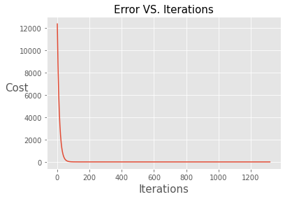

```python
# draw Error Graph
plt.plot(cost)
plt.xlabel("Iterations",fontsize=15)
plt.ylabel("Cost",rotation=0,fontsize=15)
plt.title("Error VS. Iterations",fontsize=15)
plt.show()
```

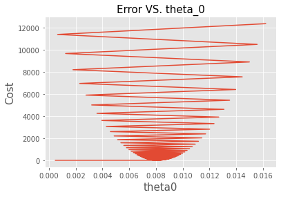

```python
# draw Error and theta0 graph
plt.plot(thetas[:,0],cost)
plt.xlabel("theta0",fontsize=15)
plt.ylabel("Cost",fontsize=15)
plt.title("Error VS. theta_0",fontsize=15)
plt.show()
```

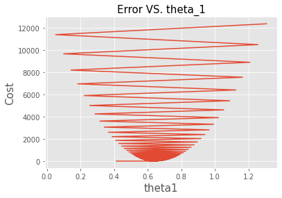

```python
# draw Error and theta1 graph
plt.plot(thetas[:,1],cost)
plt.xlabel("theta1",fontsize=15)
plt.ylabel("Cost",fontsize=15)
plt.title("Error VS. theta_1",fontsize=15)
plt.show()
```

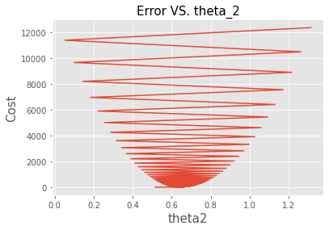

```python
# draw Error and theta2 graph
plt.plot(thetas[:,2],cost)
plt.xlabel("theta2",fontsize=15)
plt.ylabel("Cost",fontsize=15)
plt.title("Error VS. theta_2",fontsize=15)
plt.show()
```

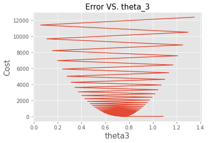

```python
# draw Error and theta3 graph
plt.plot(thetas[:,3],cost)
plt.xlabel("theta3",fontsize=15)
plt.ylabel("Cost",fontsize=15)
plt.title("Error VS. theta_3",fontsize=15)
plt.show()
```

```python
# use R2 score to evaluate LR equation output
from sklearn.metrics import r2_score

r2_score(np.asarray(y),np.asarray(f))
```

```
0.9888814345699837
```

# Bonus

## LR Using sklearn

### Single Variable

```python
# read data
dataset = pd.read_csv("RegData.csv",header=None,names=['X', 'Y'])
```

```python
# separate X (training data) from Y (target varaiable)

X = dataset.iloc[:,:-1]
Y = dataset.iloc[:,1]
```

```python
# Splitting the dataset into the Training set and Test set

from sklearn.model_selection import train_test_split
X_train, X_test, y_train, y_test = train_test_split(X, Y, test_size = 0.2, random_state = 0)
```

```python
# Fitting Simple Linear Regression to the Training set
from sklearn.linear_model import LinearRegression
regressor = LinearRegression()
regressor.fit(X_train, y_train)
```

```
LinearRegression()
```

```python
# Show Coeftion and intercept
print(regressor.coef_)
print(regressor.intercept_)
```

```
[0.76014653]
1.0695632713454648
```

```python
# Predicting the Test set results
y_pred = regressor.predict(X_test)
```

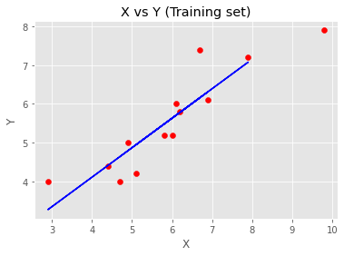

```python
# Visualising the Training set results
plt.scatter(X, Y, color = 'red')
plt.plot(X_train, regressor.predict(X_train), color = 'blue')
plt.title('X vs Y (Training set)')
plt.xlabel('X')
plt.ylabel('Y')
plt.show()
```

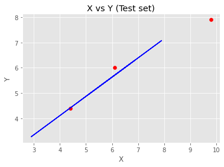

```python
# Visualising the Test set results
plt.scatter(X_test, y_test, color = 'red')
plt.plot(X_train, regressor.predict(X_train), color = 'blue')
plt.title('X vs Y (Test set)')
plt.xlabel('X')
plt.ylabel('Y')
plt.show()
```

```python
# Evalute model
from sklearn import metrics
print('Mean Absolute Error:', metrics.mean_absolute_error(y_test, y_pred))
print('Mean Squared Error:', metrics.mean_squared_error(y_test, y_pred))
print('Root Mean Squared Error:', np.sqrt(metrics.mean_squared_error(y_test, y_pred)))
```

```
Mean Absolute Error: 0.30891675107328737
Mean Squared Error: 0.15650982727398613
Root Mean Squared Error: 0.3956132293970793
```

```python
# use R2 score to evaluate LR equation output
from sklearn.metrics import r2_score

r2_score(y_test,y_pred)
```

```
0.9235294005913653
```

### Multi Variable

```python
# read data
dataset =  pd.read_csv("MultipleLR.csv",header=None,names=['X1','X2','X3','X4'])
```

```python
# separate X (training data) from Y (target varaiable)

X = m_data.iloc[:,:4]
Y = m_data.iloc[:,4]
```

```python
# Splitting the dataset into the Training set and Test set

from sklearn.model_selection import train_test_split
X_train, X_test, y_train, y_test = train_test_split(X, Y, test_size = 0.2, random_state = 0)
```

```python
# Fitting Simple Linear Regression to the Training set
from sklearn.linear_model import LinearRegression
regressor = LinearRegression()
regressor.fit(X_train, y_train)
```

```
LinearRegression()
```

```python
# Show Coeftion and intercept
print(regressor.coef_)
print(regressor.intercept_)
```

```
[0.         0.32701096 0.47623583 1.2409752 ]
-2.6910410258262516
```

```python
# Predicting the Test set results
y_pred = regressor.predict(X_test)
```

```python
# Evalute model
from sklearn import metrics
print('Mean Absolute Error:', metrics.mean_absolute_error(y_test, y_pred))
print('Mean Squared Error:', metrics.mean_squared_error(y_test, y_pred))
print('Root Mean Squared Error:', np.sqrt(metrics.mean_squared_error(y_test, y_pred)))
```

```
Mean Absolute Error: 2.4816227418519246
Mean Squared Error: 7.665280163483419
Root Mean Squared Error: 2.7686242365990044
```

```python
# use R2 score to evaluate LR equation output
from sklearn.metrics import r2_score

r2_score(y_test,y_pred)
```

```
0.9886447022939627
```